# Hot Hand Case Report

#### MGTA 453

#### Group 21:Ryan Hoag, Jingyu Song, Lakshay Anand, Qi Chu

## Part I : Regression Analysis

### Histograms of Salary, Age, FG, RB, AST, STL, BLK, and PTS.

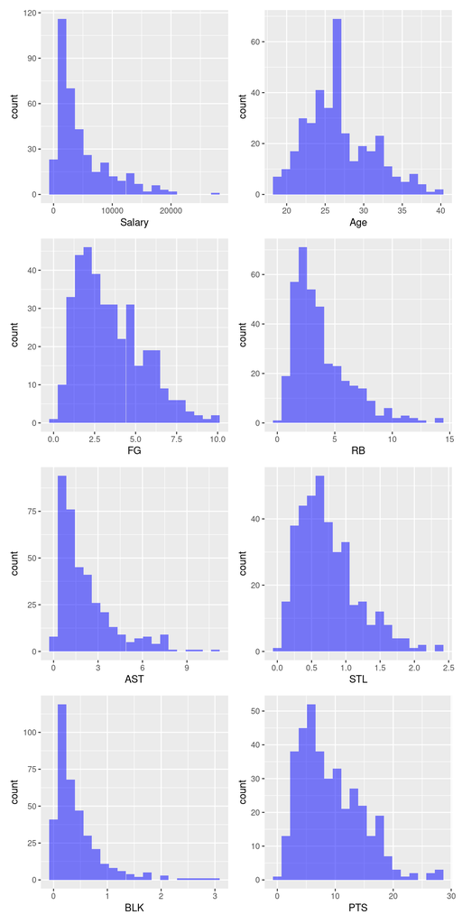

As we could tell from the above graphs, Salary,RB,AST and BLK has a relatively skewed distribution.

### Scatterplots of salary versus each of the predictors mentioned above

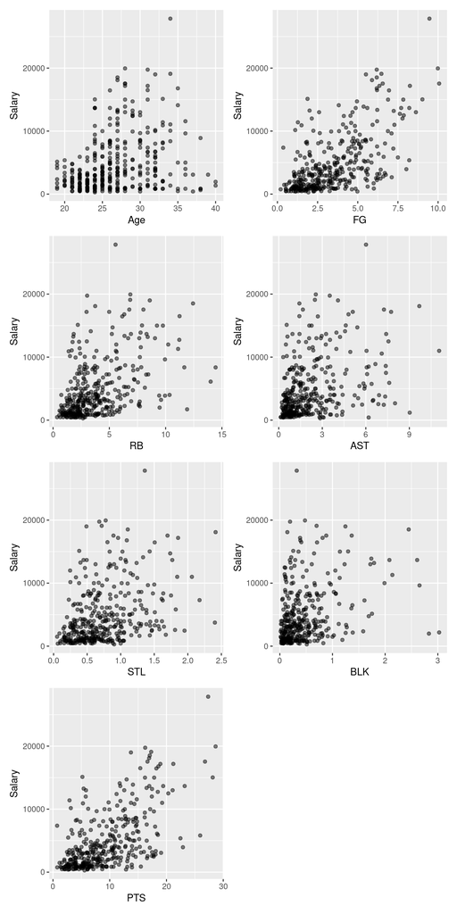

### Regression A

```
Linear regression (OLS)
Data     : nba_pgdata
Response variable    : Salary
Explanatory variables: Age, FG, RB, AST, STL, BLK
Null hyp.: the effect of x on Salary is zero
Alt. hyp.: the effect of x on Salary is not zero

             coefficient std.error t.value p.value
 (Intercept)   -8724.667  1131.833  -7.708  < .001 ***
 Age             312.092    39.520   7.897  < .001 ***
 FG             1156.982   153.881   7.519  < .001 ***
 RB              223.312   117.004   1.909   0.057 .
 AST             280.498   146.504   1.915   0.056 .
 STL           -1064.070   613.248  -1.735   0.084 .
 BLK            1071.100   517.030   2.072   0.039 *

Signif. codes:  0 '***' 0.001 '**' 0.01 '*' 0.05 '.' 0.1 ' ' 1

R-squared: 0.492,  Adjusted R-squared: 0.484
F-statistic: 58.632 df(6,363), p.value < .001
Nr obs: 370
```

#### Which predictors are significant and which ones are not?

At 99% CI: Age,FG are significant predictors  
At 95% CI: Age,FG and BLK are significant predictors  
At 90% CI: Age,FG,BLK,RB,AST,STL are all significant predictors

#### Do these regression results make sense?

Yes. The result make sense to us

#### What hypothesis test is underlying the output seen for each predictor?

Null hypothesis: the effect of x(x could be Age,FG, BLK, RB, AST, STL) on Salary is zero.  
Alternative hypothesis: the effect of x(x could be Age,FG, BLK, RB, AST, STL) on Salary is not zero. #### What do the estimated values for the coefficients mean? b0 = -8724.667 (Intersection with Y-axis. Interpret with care or ignore)  
b1= 312.092 (1 year increase in age is expected to increase salary by 312, keeping all else constant)  
b2= 1156 (1 year increase in FG is expected to increase salary by 1156, keeping all else constant)  
b3= 223 (1 unit increase in RB is expected to increase salary by 223, keeping all else constant)  
b4= 280 (1 unit increase in AST is expected to increase salary by 280, keeping all else constant)  
b5= -1064 (1 UNIT increase in STL is expected to decrease salary by 1064, keeping all else constant)  
b6= 1071 (1 unit increase in BLK is expected to increase salary by 1071, keeping all else constant)

#### Which predictor seems the most impactful?

FG is the most impactful predictor

#### How does the R2 value look? How do you interpret it?

R2 = 0.492; The values of Age,FG,BLK,RB,AST,STL account for 49.2% of the variation in the Salary

#### Intepretatiton of the Residuals vs Fittedplot.

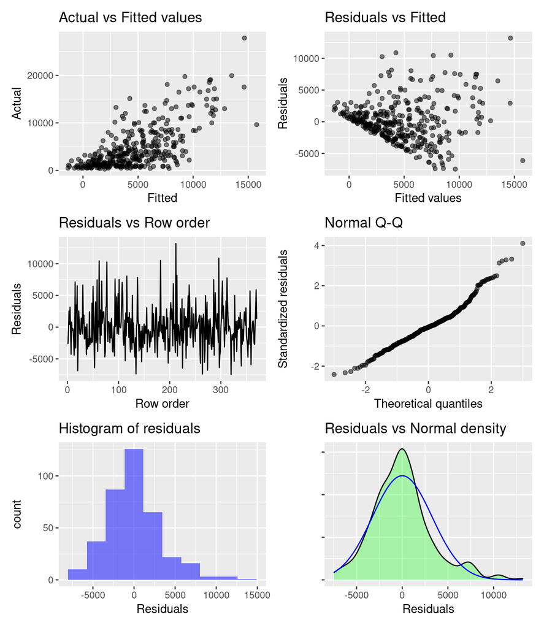

The Residuals vs Fittedplot indicates our linear regression model has heteroscedasticity.There is an incorrect setting of our model function form. If the exponential curve model is mistakenly set as a linear model, the error tends to increase. Therefore, we should apply log() to the salary variable. Take the logarithm of salary to reduce the heteroscedasticity of our model.

### Regression B

#### Comparison between Salaries and log_Salary

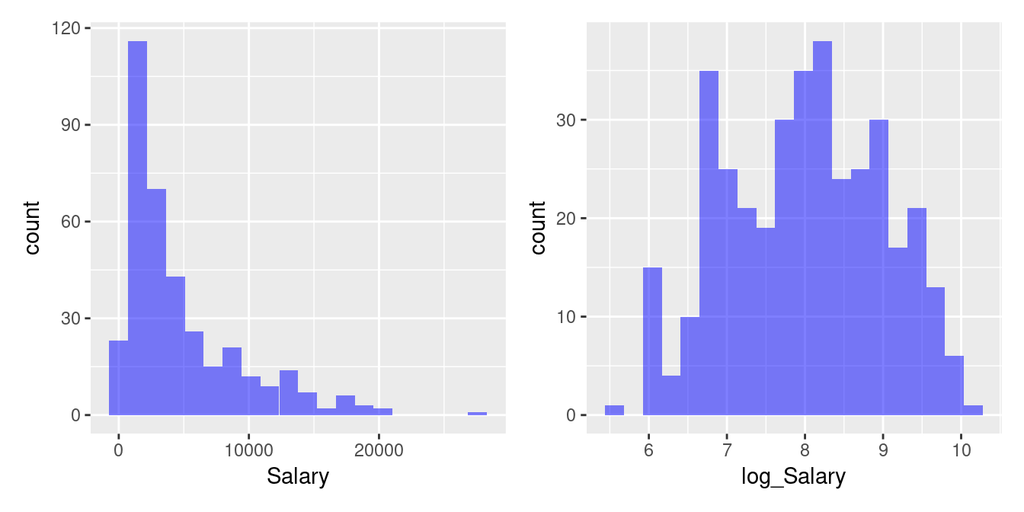

As we can see from the above 2 graph comparison, the distribution of log_Salary is less skewed after applying the log function.

```
Linear regression (OLS)
Data     : nba_pgdata
Response variable    : log_Salary
Explanatory variables: Age, FG, RB, AST, STL, BLK
Null hyp.: the effect of x on log_Salary is zero
Alt. hyp.: the effect of x on log_Salary is not zero

             coefficient std.error t.value p.value
 (Intercept)       5.302     0.255  20.803  < .001 ***
 Age               0.058     0.009   6.487  < .001 ***
 FG                0.208     0.035   5.994  < .001 ***
 RB                0.067     0.026   2.533   0.012 *
 AST               0.046     0.033   1.403   0.162
 STL               0.002     0.138   0.013   0.990
 BLK               0.210     0.116   1.807   0.072 .

Signif. codes:  0 '***' 0.001 '**' 0.01 '*' 0.05 '.' 0.1 ' ' 1

R-squared: 0.455,  Adjusted R-squared: 0.446
F-statistic: 50.599 df(6,363), p.value < .001
Nr obs: 370
```

#### Which predictors are significant and which ones are not?

At 99% CI: Age, FG are significant predictors  
At 95% CI: Age,FG and RB are significant predictors  
At 90% CI: Age,FG,BLK and RB are all significant predictors

#### Do these regression results make sense?

Yes. Make sense to us #### What hypothesis test is underlying the output seen for each predictor? Null hypothesis: the effect of x(x could be Age,FG, BLK, RB, AST, STL) on log_Salary is zero.  
Alternative hypothesis: the effect of x(x could be Age,FG, BLK, RB, AST, STL) on log_Salary is not zero. #### What do the estimated values for the coefficients mean? b0 = 5.302 (Intersection with Y-axis. Interpret with care or ignore)  
b1= 0.058 (1 year increase in age is expected to increase log_Salary by 0.058, keeping all else constant)  
b2= 0.208 (1 year increase in FG is expected to increase log_Salary by 0.208, keeping all else constant)  
b3= 0.067 (1 unit increase in RB is expected to increase log_Salary by 0.067, keeping all else constant)  
b4= 0.046 (1 unit increase in AST is expected to increase log_Salary by 0.046, keeping all else constant)  
b5= 0.002 (1 UNIT increase in STL is expected to increase log_Salary by 0.002, keeping all else constant)  
b6= 0.210 (1 unit increase in BLK is expected to increase log_Salary by 0.210, keeping all else constant)

#### Which predictor seems the most impactful?

FG

#### How does the R2 value look? How do you interpret it?

R2 = 0.455; The values of Age,FG,BLK,RB,AST,STL account for 45.5% of the variation in the log_Salary

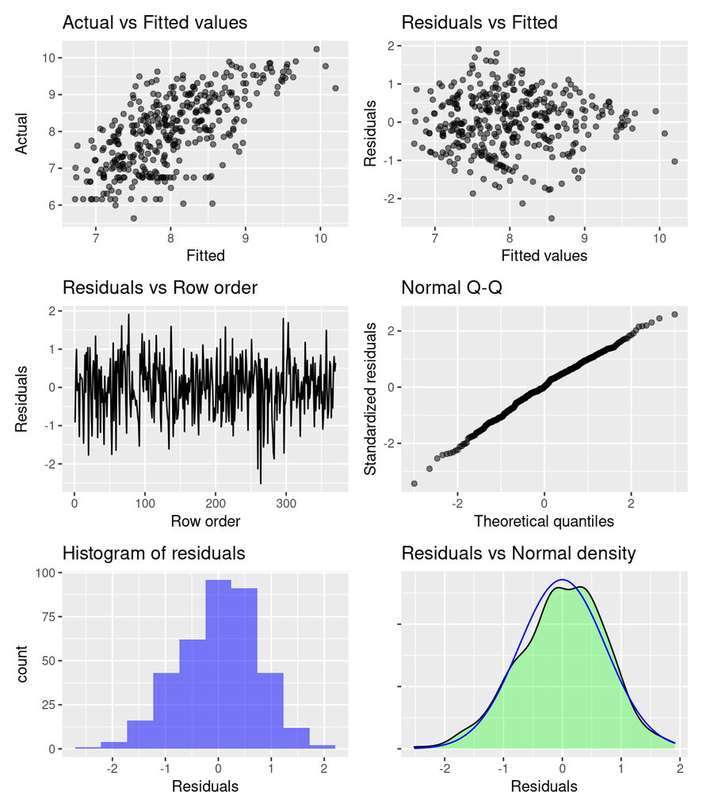

### Regression C

```
Linear regression (OLS)
Data     : nba_pgdata
Response variable    : log_Salary
Explanatory variables: Age, FG, RB, AST, STL, BLK, PTS
Null hyp.: the effect of x on log_Salary is zero
Alt. hyp.: the effect of x on log_Salary is not zero

             coefficient std.error t.value p.value
 (Intercept)       5.297     0.253  20.944  < .001 ***
 Age               0.058     0.009   6.524  < .001 ***
 FG               -0.117     0.130  -0.901   0.368
 RB                0.083     0.027   3.081   0.002 **
 AST               0.044     0.033   1.347   0.179
 STL              -0.052     0.139  -0.378   0.706
 BLK               0.251     0.117   2.153   0.032 *
 PTS               0.120     0.046   2.592   0.010 **

Signif. codes:  0 '***' 0.001 '**' 0.01 '*' 0.05 '.' 0.1 ' ' 1

R-squared: 0.465,  Adjusted R-squared: 0.455
F-statistic: 45.013 df(7,362), p.value < .001
Nr obs: 370
```

#### What happens to the regression results?

The strong predictor FG (as indicated in the above 2 models) appeared to be not significant in this model after adding PTS. A possible explanation is that FG and PTS is highly correlated, so adding PTS distorted our model’s evaluation of the FG predictor.

### Regression D

```
Linear regression (OLS)
Data     : nba_pgdata
Response variable    : log_Salary
Explanatory variables: Age, RB, AST, STL, BLK, PTS
Null hyp.: the effect of x on log_Salary is zero
Alt. hyp.: the effect of x on log_Salary is not zero
**Standardized coefficients shown (2 X SD)**

             coefficient std.error t.value p.value
 (Intercept)      -0.000     0.019  -0.000   1.000
 Age               0.254     0.039   6.544  < .001 ***
 RB                0.185     0.063   2.953   0.003 **
 AST               0.079     0.062   1.266   0.206
 STL              -0.018     0.060  -0.301   0.763
 BLK               0.111     0.054   2.045   0.042 *
 PTS               0.428     0.066   6.513  < .001 ***

Signif. codes:  0 '***' 0.001 '**' 0.01 '*' 0.05 '.' 0.1 ' ' 1

R-squared: 0.464,  Adjusted R-squared: 0.455
F-statistic: 52.407 df(6,363), p.value < .001
Nr obs: 370
```

#### How does using standardized coefficients change the interpretation of the regression results?

The Standardized coefficients rescale the variables. So now the intercept now has coefficient of 0

## Part II : Hot Hand Hypothesis Testing

### * Statistical point of view:

We performed a single side compare mean test (mean of P(hit) and mean of P(hit|hit) of 9 players) and below is the test result

```
Pairwise mean comparisons (t-test)
Data      : from_clipboard
Variables : P_hit_, P_hit_1_hit_
Samples   : independent
Confidence: 0.95
Adjustment: None

               mean n n_missing    sd    se    me
       P_hit_ 0.517 9         0 0.052 0.017 0.040
 P_hit_1_hit_ 0.502 9         0 0.048 0.016 0.037

 Null hyp.               Alt. hyp.               diff  p.value
 P_hit_ = P_hit_1_hit_   P_hit_ < P_hit_1_hit_   0.014 0.725

Signif. codes:  0 '***' 0.001 '**' 0.01 '*' 0.05 '.' 0.1 ' ' 1
```

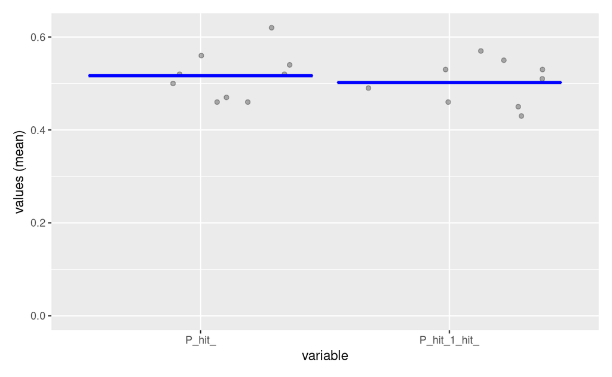

#### What is the null hypothesis (“the something else”)? What are you hoping to show (alternative hypothesis)?

Null hypothesis: P(hit) = P(hit|hit)  
Alternative hypothesis: P(hit) < P(hit|hit)

#### How much data do you have here?

We have the probability of hit, conditional probability of hit given a previous miss or hit of 9 players.

#### What distribution is appropriate?

We think a t distribution is appropriate for this hypothesis test

#### What conclusions can you draw from your test?

Since the p value of this hypothesis testing is 0.725, we do not reject the null hypothesis

### Streaks Approach

Based on our simulation model, we filled out the table with missing values as below

| Players | nshots | actualruns | ExpectedRuns | SdRuns | Expected_below_actual |
| --- | --- | --- | --- | --- | --- |
| PlayerA | 248 | 128 | 124.5374 | 7.912109 | 0.6472 |
| PlayeB | 884 | 431 | 441.9474 | 14.888761 | 0.2259 |
| PlayerC | 419 | 203 | 208.7339 | 10.160877 | 0.2706 |
| PlayerD | 339 | 172 | 167.6963 | 9.292712 | 0.6579 |
| PlayerE | 272 | 134 | 135.9896 | 8.257452 | 0.3780 |
| PlayerF | 451 | 245 | 224.5715 | 10.636456 | 0.9702 |
| PlayerG | 433 | 227 | 215.7214 | 10.398048 | 0.8527 |
| PlayerH | 351 | 176 | 175.8856 | 9.362515 | 0.4840 |
| PlayerI | 403 | 220 | 190.3170 | 10.474459 | 0.9984 |

In order to test whether the actual run numbers were substantially less than the mean it was first prudent to take a t.test of each of the sample distributions as compared to the actual number of runs. This test would significantly distinguish the actual run number from the simulation mean but would not provide enough proof on its own that the run number was low enough to provide credence to the hot hand theory. We cast our net pretty wide to be sure the actual run number was as far away from the mean as we could. Notably 3 were significantly distinguishable from the mean but at least ⅔ did not provide compelling proof. One had a difference between the actual score and the simulated mean of only 1.9 runs. The only interesting note here is once again B, which has an estimated difference of about 10 runs. This is in line with previous statistics.

One Sample t-test data: runs_list t = 74.068, df = 9999, p-value < 2.2e-16 alternative hypothesis: true mean is greater than 431 99.9 percent confidence interval: 441.5711 Inf sample estimates: mean of x 442.0315

One Sample t-test data: runs_list t = 53.165, df = 9999, p-value < 2.2e-16 alternative hypothesis: true mean is greater than 203 99.9 percent confidence interval: 208.1795 Inf sample estimates: mean of x 208.4992

One Sample t-test data: runs_list t = 22.976, df = 9999, p-value < 2.2e-16 alternative hypothesis: true mean is greater than 134 99.9 percent confidence interval: 135.6502 Inf sample estimates: mean of x 135.9067

## Part III : Critical Thinking

#### What might make the hot hand easier or more difficult to observe in either sport?

In basketball, a heat map showing where players shoot can be used to differentiate types of shots so difficult 3-point shots aren’t being compared to relatively more simple lay-ups. In baseball, players have fewer opportunities as well as times to hit the ball and also the time gap between each hit is longer, which makes data points sparse and harder for researchers to observe certain trends.

#### What would you need to do in order to establish that the hot hand exists in basketball?

Our best approach in both cases would be to create a more controlled environment to test a multitude of players attempting to make similar shots. In both cases a player’s ability to score a basket or hit may be controlled as much by the other team as the attempting player themselves. Limiting the number of variables will be key to attributing differences in scoring percentages to the hot hand theory itself. The baseball players may want to set up in a batting cage to increase the frequency of observations and control for the opposing team, while basketball players may want to run shooting drills rather than record shots in a tense game.

#### How would you build a regression model to try to establish that a hot hand exists?

We will build a Logistic regression. Each observation is one shot attempt of one player in various circumstances explained by the additional variables.  
Response variable: hit or miss (1-0)  
Dummy variable: hit/miss of previous attempt (1-0)  
Categorical variable: type of match/ activity (drill, pitched game, blowout game [leads of 30 or more])  
Categorical variable: type of attempt (3-point, lay-up, 2-point shot)  
Numerical variable: number of attempts made previously (min = 0)  
Numerical variable: number of successful hits in the run so far (min = 0)  
Numerical variable: salary of the specific player (in 1000s)

#### What would be critical predictor variables?

The numerical variable stating the number of hits made previously would be the key variable here, with most of the others serving as control variables to differentiate different types of shots and eliminate potential confounds. In addition it would be interesting to see if the more skill based shots such as 3 pointers had a higher hot hand effect.

#### How much data would you need?

Ideally we would want to have a large amount of data for each player, at least 500 shots per player for a significant number of players. At least 1000 in this case. We would also want to control for different circumstances such as ‘in game’ or ‘performing drills’. Keeping data separated by activity, player, and shot type would be essential. We can also have the data for a number of games, which will give us a chance to look at the player’s scoring patterns to help us identify whether a hot-hand kind of scenario really exists.